# Lab-11 Replication File

## Introduction

This notebook replicates the lab for week 11.

## Dependencies

This notebook requires the following packages:

```r
library(effsize)
library(dplyr)
library(ggplot2)
library(psych)
library(pwr)
library(stargazer)
library(testDriveR)
```

We also use the following custom function for creating correlation tables:

```r
corrTable <-function(.data, coef = c("pearson", "spearman"), listwise = TRUE, round = 3, pStar = TRUE, ...){
  ## process dots
  if (rlang::dots_n(...) > 1) {
    .data <- dplyr::select(.data, ...)
  }

  ## listwise deletion
  if (listwise == TRUE) {
    .data <- na.omit(.data)
  }

  ## compute correlation matrix
  inputMatrix <- as.matrix(.data)
  corrMatrix <- Hmisc::rcorr(inputMatrix, type = coef)

  ## matrix of correlation coeficients
  rCoef <- corrMatrix$r

  # matrix of p-values
  pValues <- corrMatrix$P

  ## round the correlation matrix values
  rCoef <- format(round(cbind(rep(-1.11, ncol(.data)), rCoef), round))[,-1]

  ## statistical significance stars
  if (pStar == TRUE) {

    ## Define notions for significance levels
    stars <- ifelse(pValues < .001, "***",
                    ifelse(pValues < .01, "**",
                           ifelse(pValues < .05, "*", "")))

    ## add apropriate stars
    rCoef <- matrix(paste(rCoef, stars, sep = ""), ncol = ncol(.data))
  }

  ## remove upper triangle
  rCoef[upper.tri(rCoef, diag = FALSE)] <- ""
  diag(rCoef) <- formatC(1, digits = round, format = "f")

  ## final formatting
  rCoef <- as.data.frame(rCoef)
  rCoef <- dplyr::mutate_if(rCoef, is.factor, as.character)
  rownames(rCoef) <- colnames(.data)
  colnames(rCoef) <- paste(colnames(.data), "", sep = "")

  ## return data frame
  return(rCoef)
}
```

## Data

We’ll assign the data for the lab to a new object named `autoData`.

```r
autoData <- auto17
```

## Part 1: Correlation in `R`

### Question 1

The following syntax creates a correlation table for the variables `combFE`, `fuelCost`, and `cyl`.

```r
table <- corrTable(autoData, coef = "pearson", listwise = TRUE, round = 3, pStar = TRUE, combFE, fuelCost, cyl)
table
```

|  | combFE | fuelCost | cyl |
| --- | --- | --- | --- |
| combFE | 1.000 |  |  |
| fuelCost | -0.899*** | 1.000 |  |
| cyl | -0.723*** | 0.843*** | 1.000 |

### Question 2

There is a strong, negative relationship between combined fuel efficiency and fuel cost ($r = -.899, p < .001$). The higher the fuel cost, the lower the fuel efficiency of the vehicle.

### Question 3

There is a strong, positive relationship between fuel cost and number of cylinders ($r = .843, p < .001$). The higher the number of cylinders in the engine, the higher the fuel cost of the vehicle.

### Question 4

There is a strong, negative relationship between combined fuel efficiency and number of cylinders ($r = -.723, p < .001$). The higher the number of cylinders in the engine, the lower the fuel efficiency of the vehicle.

### Question 5

The following code creates a LaTeX formatted table

```r
stargazer(table, title = "Correlation Table for Vehicle Efficiency", summary = FALSE)
```

```
% Table created by stargazer v.5.2 by Marek Hlavac, Harvard University. E-mail: hlavac at fas.harvard.edu
% Date and time: Mon, Nov 13, 2017 - 15:45:59
\begin{table}[!htbp] \centering
  \caption{Correlation Table for Vehicle Efficiency}
  \label{}
\begin{tabular}{@{\extracolsep{5pt}} cccc}
\\[-1.8ex]\hline
\hline \\[-1.8ex]
 & combFE & fuelCost & cyl \\
\hline \\[-1.8ex]
combFE & 1.000 &  &  \\
fuelCost & -0.899\textasteriskcentered \textasteriskcentered \textasteriskcentered  & 1.000 &  \\
cyl & -0.723\textasteriskcentered \textasteriskcentered \textasteriskcentered  &  0.843\textasteriskcentered \textasteriskcentered \textasteriskcentered  & 1.000 \\
\hline \\[-1.8ex]
\end{tabular}
\end{table}
```

## Part 2: Scatterplots

### Question 6

The following code produces a scatterplot between the variables `combFE` and `fuelCost`.

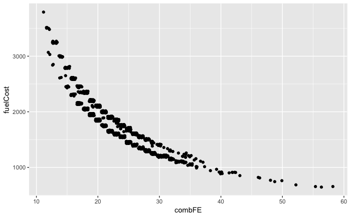

```r
ggplot(data = autoData) +
  geom_point(mapping = aes(x = combFE, y = fuelCost), position = "jitter")
```

We can see a clear, if non-linear, relationship between the two variables. As fuel efficiency increases, the cost of fuel declines.

### Question 7

The following code creates a binary variable representing gas guzzling vehicles (as defined by the federal Department of Transportation).

```r
autoData <- mutate(autoData, guzzlerLog = ifelse(guzzlerStr == "G", TRUE, FALSE))
```

### Question 8

We can use the new guzzler variable to color the points of our scatterplot.

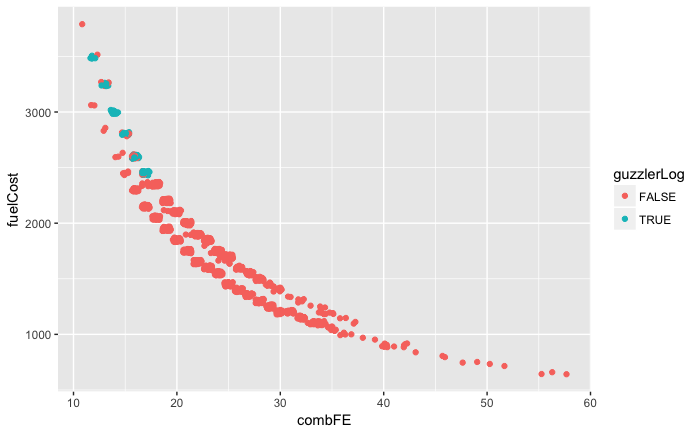

```r
ggplot(data = autoData) +
  geom_point(mapping = aes(x = combFE, y = fuelCost, color = guzzlerLog), position = "jitter")
```

This plot shows that all of the guzzler vehicles have both high fuel cost and lost fuel efficiency.

### Question 9

We can also use the new guzzler variable as a faceting variable to more clearly highlight the pattern unique to guzzlers.

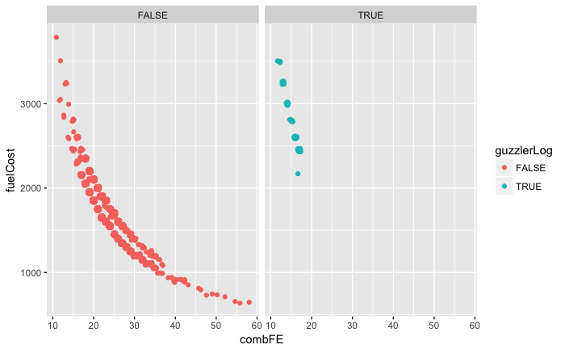

```r
ggplot(data = autoData) +
  geom_point(mapping = aes(x = combFE, y = fuelCost, color = guzzlerLog), position = "jitter") +
  facet_wrap( ~ guzzlerLog)
```

### Question 10

This produces an error - apologies!

## Part 3: Cronbach’s Alpha

### Question 11

The following code creates a subset of the `autoData` data frame, and then calculates a Cronbach’s alpha value from it.

```r
autoData %>%
  select(combFE, fuelCost, cyl) -> autoSelection
psych::alpha(autoSelection, check.keys = TRUE)
```

```
Some items were negatively correlated with total scale and were automatically reversed.
 This is indicated by a negative sign for the variable name.
```

```
Reliability analysis
Call: psych::alpha(x = autoSelection, check.keys = TRUE)

  raw_alpha std.alpha G6(smc) average_r S/N     ase mean  sd
     0.043      0.93    0.93      0.82  14 0.00045 1859 159

 lower alpha upper     95% confidence boundaries
0.04 0.04 0.04

 Reliability if an item is dropped:
         raw_alpha std.alpha G6(smc) average_r  S/N alpha se
combFE-      0.014      0.92    0.84      0.84 10.8  0.00025
fuelCost     0.598      0.84    0.72      0.72  5.2  0.01039
cyl          0.044      0.95    0.90      0.90 17.7  0.00060

 Item statistics
            n raw.r std.r r.cor r.drop   mean    sd
combFE-  1216  0.90  0.93  0.90   0.90 3779.7   5.8
fuelCost 1216  1.00  0.97  0.97   0.93 1791.4 470.1
cyl      1216  0.84  0.91  0.84   0.84    5.6   1.9
```

The alpha value ($alpha = .93$) is particularly high, suggesting that there may be an underlying construct (engine efficiency) that all three of these variables measure.

## Part 4: Sample Size Estimates

## Question 12

The following code calculates an estimated sample size for the given parameters.

```r
pwr.r.test(r = .89, sig.level = .05, power = .8, alternative = "two.sided")
```

```
     approximate correlation power calculation (arctangh transformation)

              n = 6.483499
              r = 0.89
      sig.level = 0.05
          power = 0.8
    alternative = two.sided
```

We would need a sample of at least 7 people (in reality, 30) to see this effect size ($r=.89$) at the given level of power ($power = .8$)

## Question 13

The following code calculates an estimated sample size for the given parameters.

```r
pwr.r.test(r = .29, sig.level = .05, power = .9, alternative = "two.sided")
```

```
     approximate correlation power calculation (arctangh transformation)

              n = 119.9989
              r = 0.29
      sig.level = 0.05
          power = 0.9
    alternative = two.sided
```

We would need a sample of at least 120 people to see this effect size ($r=.29$) at the given level of power ($power = .9$)